#### Data Description

**mushroom.csv** contains 8124 rows of different descriptions of hypothetical samples corresponding to 23 species of gilled mushrooms in the Agaricus and Lepiota Family Mushroom drawn from The Audubon Society Field Guide to North American Mushrooms (1981)

**class** - e = edible, p = poisonous.

**cap-shape**: bell=b,conical=c,convex=x,flat=f, knobbed=k,sunken=s

**cap-surface**: fibrous=f,grooves=g,scaly=y,smooth=s

**cap-color**: brown=n,buff=b,cinnamon=c,gray=g,green=r,pink=p,purple=u,red=e,white=w,yellow=y

**bruises**: bruises=t,no=f

**odor**: almond=a,anise=l,creosote=c,fishy=y,foul=f,musty=m,none=n,pungent=p,spicy=s

**gill-attachment**: attached=a,descending=d,free=f,notched=n

**gill-spacing**: close=c,crowded=w,distant=d

**gill-size**: broad=b,narrow=n

**gill-color**: black=k,brown=n,buff=b,chocolate=h,gray=g, green=r,orange=o,pink=p,purple=u,red=e,white=w,yellow=y

**stalk-shape**: enlarging=e,tapering=t

**stalk-root**: bulbous=b,club=c,cup=u,equal=e,rhizomorphs=z,rooted=r,missing=?

**stalk-surface-above-ring**: fibrous=f,scaly=y,silky=k,smooth=s

**stalk-surface-below-ring**: fibrous=f,scaly=y,silky=k,smooth=s

**stalk-color-above-ring**: brown=n,buff=b,cinnamon=c,gray=g,orange=o,pink=p,red=e,white=w,yellow=y

**stalk-color-below-ring**: brown=n,buff=b,cinnamon=c,gray=g,orange=o,pink=p,red=e,white=w,yellow=y

**veil-type**: partial=p,universal=u

**veil-color**: brown=n,orange=o,white=w,yellow=y

**ring-number**: none=n,one=o,two=t

**ring-type**: cobwebby=c,evanescent=e,flaring=f,large=l,none=n,pendant=p,sheathing=s,zone=z

**spore-print-color**: black=k,brown=n,buff=b,chocolate=h,green=r,orange=o,purple=u,white=w,yellow=y

**population**: abundant=a,clustered=c,numerous=n,scattered=s,several=v,solitary=y

**habitat**: grasses=g,leaves=l,meadows=m,paths=p,urban=u,waste=w,woods=d

#### **Packages**

```r
library(knitr)
install.packages("lattice")
install.packages("caret")
install.packages("caret", dependencies = TRUE)
update.packages(oldPkgs="caret", ask=FALSE)
```

```
## will not be updated
```

```
## will not be updated
```

```r
install.packages("MASS")
install.packages("dplyr")
install.packages("arm")
install.packages("adabag")
install.packages("fastAdaboost")
library(adabag)
library(rpart)
library(ISLR)
library(MASS)
library(arm)
library(car)
library(caret)
library(pROC)
```

```r
library(corrplot)
library(psych)
library(ggplot2)
library(ISLR)
library(class)
library(dplyr)
library(randomForest)
library(rpart)
library(rpart.plot)
library(rattle)
```

#### **1. Upload the data**

```r
data_org1 = read.csv('mushrooms.csv', colClasses=c(rep('factor',23)))
colnames(data_org1)
```

```
##  [1] "class"                    "cap.shape"
##  [3] "cap.surface"              "cap.color"
##  [5] "bruises"                  "odor"
##  [7] "gill.attachment"          "gill.spacing"
##  [9] "gill.size"                "gill.color"
## [11] "stalk.shape"              "stalk.root"
## [13] "stalk.surface.above.ring" "stalk.surface.below.ring"
## [15] "stalk.color.above.ring"   "stalk.color.below.ring"
## [17] "veil.type"                "veil.color"
## [19] "ring.number"              "ring.type"
## [21] "spore.print.color"        "population"
## [23] "habitat"
```

```r
dim(data_org1)
```

```
## [1] 8124   23
```

```r
# is.factor(data_org$class)
# Check for missing values
# is.na(data_org) - output is too long # False will be treated as 0, True will be treated as 1
sum(is.na(data_org1))
```

```
## [1] 0
```

```r
data_org1$stalk.root <- gsub("?",NA,data_org1$stalk.root, fixed = TRUE)
# is.na(data_org1)
sum(is.na(data_org1))
```

```
## [1] 2480
```

```r
data_org <- na.omit(data_org1)
dim(data_org)
```

```
## [1] 5644   23
```

```r
# summary(data_org)
str(data_org)
```

```
## 'data.frame':    5644 obs. of  23 variables:
##  $ class                   : Factor w/ 2 levels "e","p": 2 1 1 2 1 1 1 1 2 1 ...
##  $ cap.shape               : Factor w/ 6 levels "b","c","f","k",..: 6 6 1 6 6 6 1 1 6 1 ...
##  $ cap.surface             : Factor w/ 4 levels "f","g","s","y": 3 3 3 4 3 4 3 4 4 3 ...
##  $ cap.color               : Factor w/ 10 levels "b","c","e","g",..: 5 10 9 9 4 10 9 9 9 10 ...
##  $ bruises                 : Factor w/ 2 levels "f","t": 2 2 2 2 1 2 2 2 2 2 ...
##  $ odor                    : Factor w/ 9 levels "a","c","f","l",..: 7 1 4 7 6 1 1 4 7 1 ...
##  $ gill.attachment         : Factor w/ 2 levels "a","f": 2 2 2 2 2 2 2 2 2 2 ...
##  $ gill.spacing            : Factor w/ 2 levels "c","w": 1 1 1 1 2 1 1 1 1 1 ...
##  $ gill.size               : Factor w/ 2 levels "b","n": 2 1 1 2 1 1 1 1 2 1 ...
##  $ gill.color              : Factor w/ 12 levels "b","e","g","h",..: 5 5 6 6 5 6 3 6 8 3 ...
##  $ stalk.shape             : Factor w/ 2 levels "e","t": 1 1 1 1 2 1 1 1 1 1 ...
##  $ stalk.root              : chr  "e" "c" "c" "e" ...
##  $ stalk.surface.above.ring: Factor w/ 4 levels "f","k","s","y": 3 3 3 3 3 3 3 3 3 3 ...
##  $ stalk.surface.below.ring: Factor w/ 4 levels "f","k","s","y": 3 3 3 3 3 3 3 3 3 3 ...
##  $ stalk.color.above.ring  : Factor w/ 9 levels "b","c","e","g",..: 8 8 8 8 8 8 8 8 8 8 ...
##  $ stalk.color.below.ring  : Factor w/ 9 levels "b","c","e","g",..: 8 8 8 8 8 8 8 8 8 8 ...
##  $ veil.type               : Factor w/ 1 level "p": 1 1 1 1 1 1 1 1 1 1 ...
##  $ veil.color              : Factor w/ 4 levels "n","o","w","y": 3 3 3 3 3 3 3 3 3 3 ...
##  $ ring.number             : Factor w/ 3 levels "n","o","t": 2 2 2 2 2 2 2 2 2 2 ...
##  $ ring.type               : Factor w/ 5 levels "e","f","l","n",..: 5 5 5 5 1 5 5 5 5 5 ...
##  $ spore.print.color       : Factor w/ 9 levels "b","h","k","n",..: 3 4 4 3 4 3 3 4 3 3 ...
##  $ population              : Factor w/ 6 levels "a","c","n","s",..: 4 3 3 4 1 3 3 4 5 4 ...
##  $ habitat                 : Factor w/ 7 levels "d","g","l","m",..: 6 2 4 6 2 2 4 4 2 4 ...
##  - attr(*, "na.action")=Class 'omit'  Named int [1:2480] 3985 4024 4077 4101 4105 4197 4201 4284 4292 4327 ...
##   .. ..- attr(*, "names")= chr [1:2480] "3985" "4024" "4077" "4101" ...
```

```r
# --------- To convert the dataset to Numeric ------------------
# numeric_data = raw.data[,2:23]
# class = raw.data[,1]

# numeric_data <- sapply(numeric_data, function (x) as.numeric(as.factor(x)))
# --------------------------------------------------

data_table <- lapply(seq(from=2, to=ncol(data_org)),
                         function(x) {table(data_org$class, data_org[,x])})
names(data_table) <- colnames(data_org)[2:ncol(data_org)]
for(i in 1:length(data_table)) {
    cat(i,"-",names(data_table)[i],":levels:",length(levels(data_org[[i+1]])), "\n")
    cat("-----------------------------------------------------------------")
    print(data_table[[i]])
    cat("\n\n")
}
```

```
## 1 - cap.shape :levels: 6
## -----------------------------------------------------------------
##        b    c    f    k    s    x
##   e  260    0 1460   20   32 1716
##   p   40    4  972   16    0 1124
##
##
## 2 - cap.surface :levels: 4
## -----------------------------------------------------------------
##        f    g    s    y
##   e 1416    0  712 1360
##   p  744    4  548  860
##
##
## 3 - cap.color :levels: 10
## -----------------------------------------------------------------
##        b    c    e    g    n    p    r    u    w    y
##   e    0   32  576  888 1024    8    0    0  560  400
##   p  120   12   12  808  140   88    0    0  320  656
##
##
## 4 - bruises :levels: 2
## -----------------------------------------------------------------
##        f    t
##   e  928 2560
##   p 1532  624
##
##
## 5 - odor :levels: 9
## -----------------------------------------------------------------
##        a    c    f    l    m    n    p    s    y
##   e  400    0    0  400    0 2688    0    0    0
##   p    0  192 1584    0   36   88  256    0    0
##
##
## 6 - gill.attachment :levels: 2
## -----------------------------------------------------------------
##        a    f
##   e    0 3488
##   p   18 2138
```

[output cut: 97 more lines]

```
##   p    0 1584  224  224    0   72    0   52    0
##
##
## 21 - population :levels: 6
## -----------------------------------------------------------------
##        a    c    n    s    v    y
##   e  384    0  256  736 1072 1040
##   p    0   52    0  368 1088  648
##
##
## 22 - habitat :levels: 7
## -----------------------------------------------------------------
##        d    g    l    m    p    u    w
##   e 1832 1120   48  256  136   96    0
##   p  660  740   16   36  432  272    0
```

```r
length(data_table)
```

```
## [1] 22
```

#### **Exploring the Data Set**

```r
dim(data_org)
```

```
## [1] 5644   23
```

```r
library(gridExtra)
```

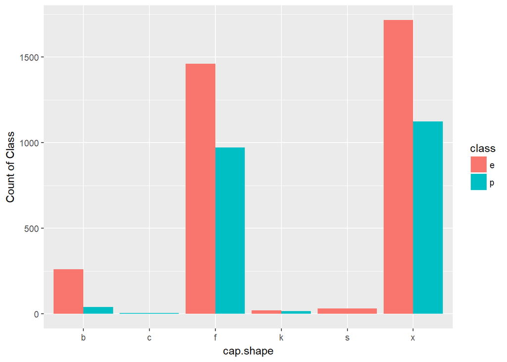

```r
install.packages("ggplot2")
library(ggplot2)

hist1 <- ggplot( data_org, aes( x = data_org$cap.shape, fill = class )) + geom_bar(stat='count', position='dodge') + labs(x = 'cap.shape', y = 'Count of Class')
hist1
```

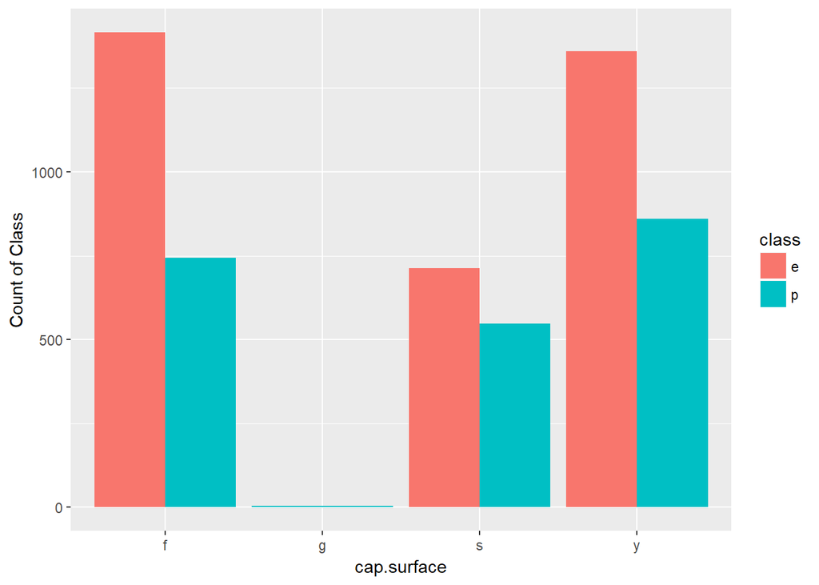

```r
hist2 <- ggplot( data_org, aes( x = data_org$cap.surface, fill = class )) + geom_bar(stat='count', position='dodge') + labs(x = 'cap.surface', y = 'Count of Class')
hist2
```

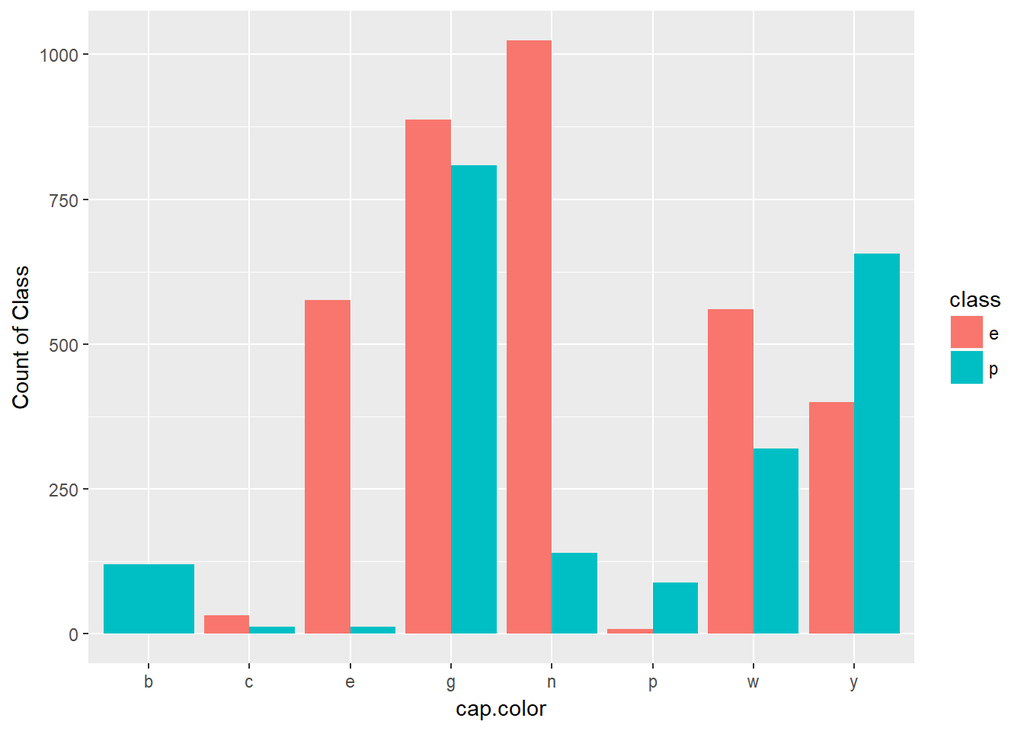

```r
hist3 <- ggplot( data_org, aes( x = data_org$cap.color, fill = class )) + geom_bar(stat='count', position='dodge') + labs(x = 'cap.color', y = 'Count of Class')
hist3
```

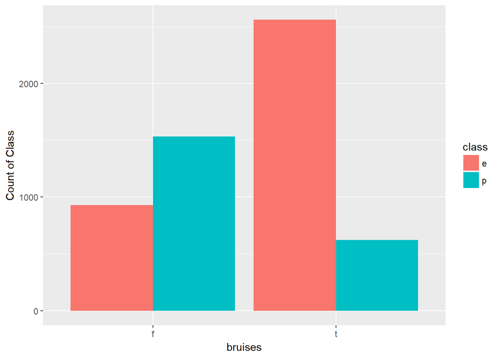

```r
hist4 <- ggplot( data_org, aes( x = data_org$bruises, fill = class )) + geom_bar(stat='count', position='dodge') + labs(x = 'bruises', y = 'Count of Class')
hist4
```

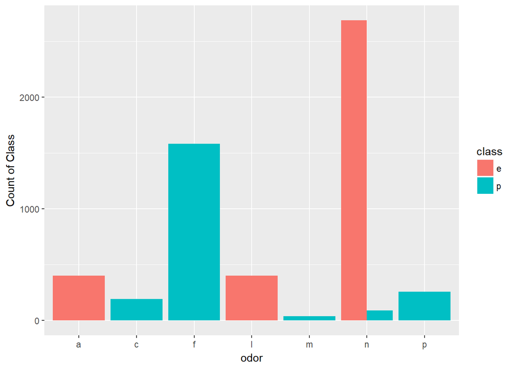

```r
hist5 <- ggplot( data_org, aes( x = data_org$odor, fill = class )) + geom_bar(stat='count', position='dodge') + labs(x = 'odor', y = 'Count of Class')
hist5
```

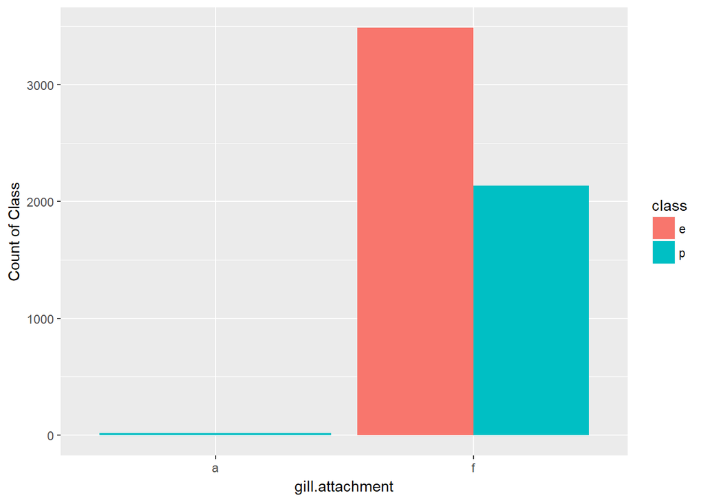

```r
hist6 <- ggplot( data_org, aes( x = data_org$gill.attachment, fill = class )) + geom_bar(stat='count', position='dodge') + labs(x = 'gill.attachment', y = 'Count of Class')
hist6
```

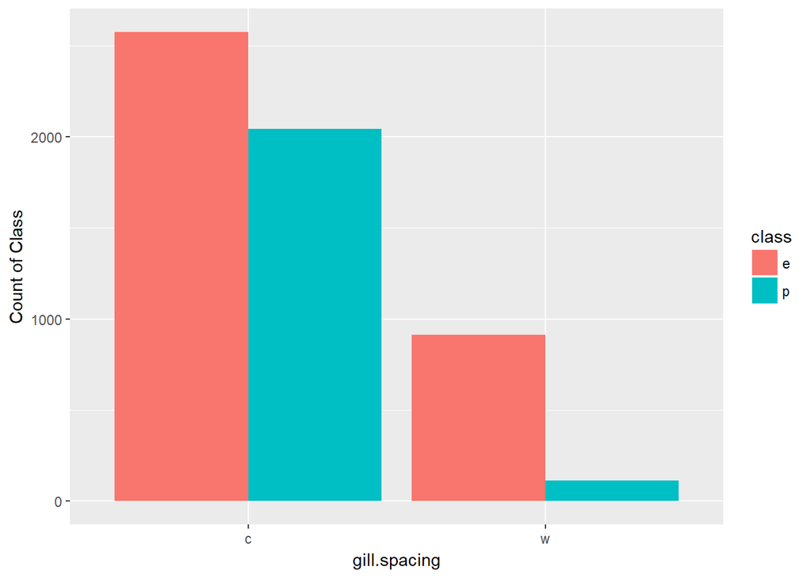

```r
hist7 <- ggplot( data_org, aes( x = data_org$gill.spacing, fill = class )) + geom_bar(stat='count', position='dodge') + labs(x = 'gill.spacing', y = 'Count of Class')
hist7
```

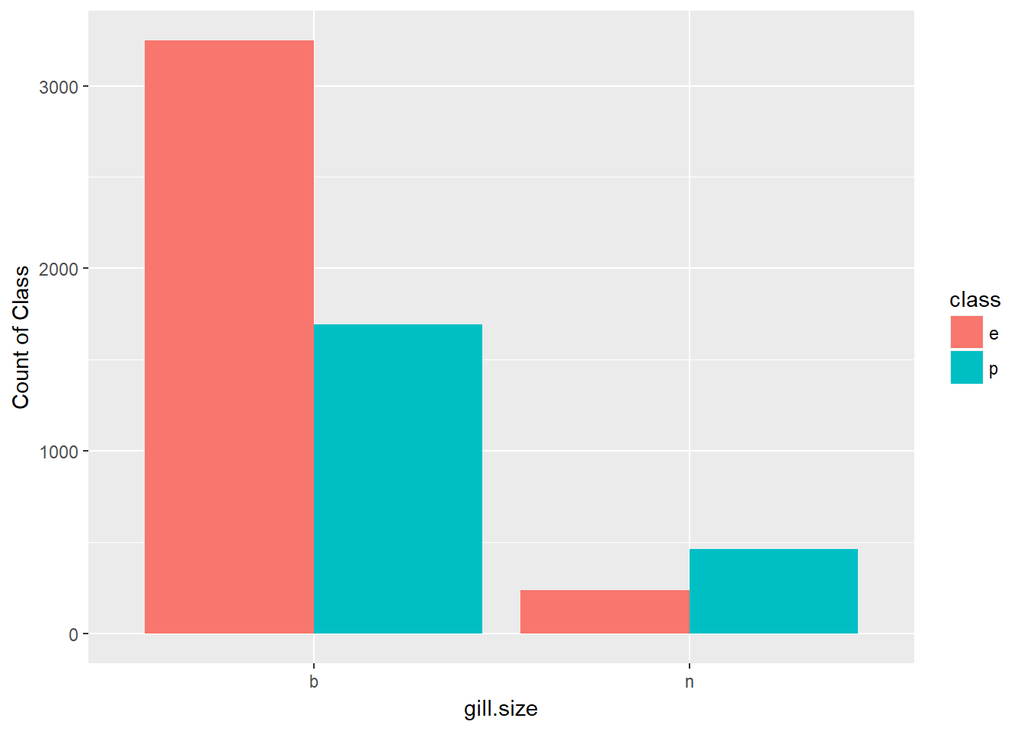

```r
hist8 <- ggplot( data_org, aes( x = data_org$gill.size, fill = class )) + geom_bar(stat='count', position='dodge') + labs(x = 'gill.size', y = 'Count of Class')
hist8
```

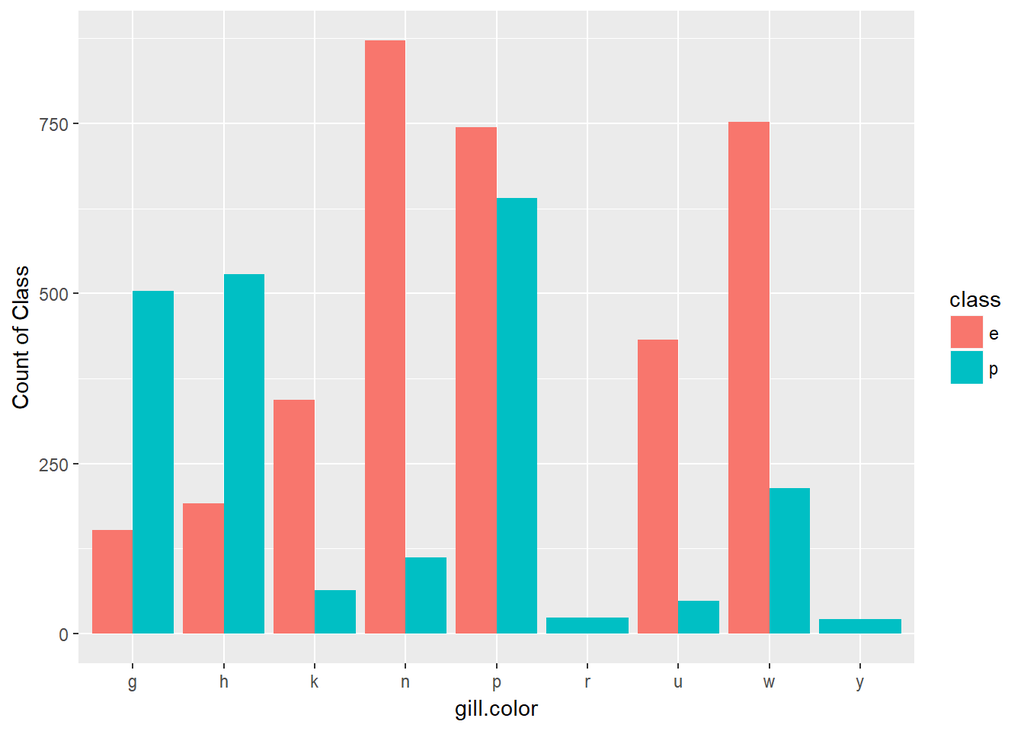

```r
hist9 <- ggplot( data_org, aes( x = data_org$gill.color, fill = class )) + geom_bar(stat='count', position='dodge') + labs(x = 'gill.color', y = 'Count of Class')
hist9
```

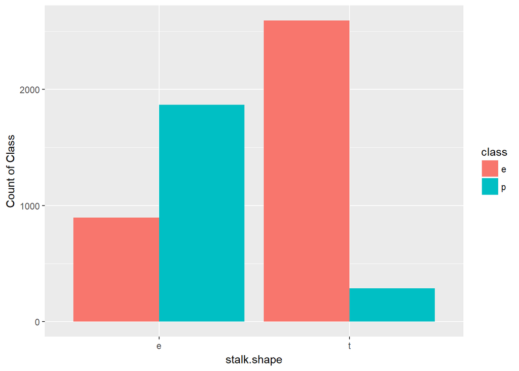

```r
hist10 <- ggplot( data_org, aes( x = data_org$stalk.shape, fill = class )) + geom_bar(stat='count', position='dodge') + labs(x = 'stalk.shape', y = 'Count of Class')
hist10
```

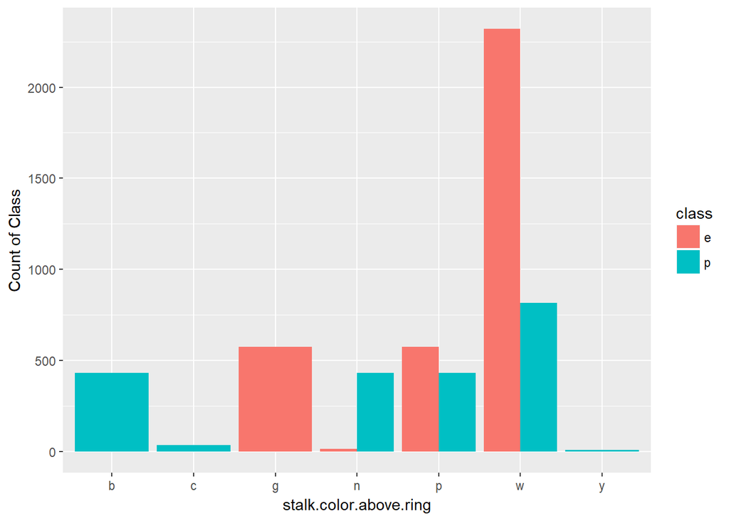

```r
hist11 <- ggplot( data_org, aes( x = data_org$stalk.color.above.ring, fill = class )) + geom_bar(stat='count', position='dodge') + labs(x = 'stalk.color.above.ring', y = 'Count of Class')
hist11
```

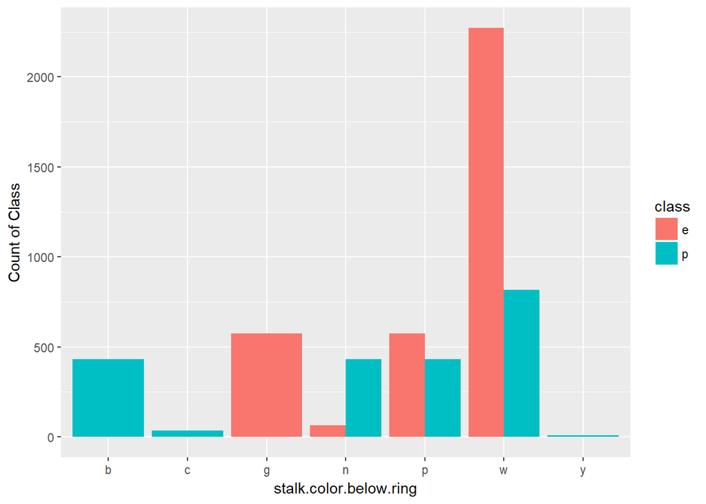

```r
hist12 <- ggplot( data_org, aes( x = data_org$stalk.color.below.ring, fill = class )) + geom_bar(stat='count', position='dodge') + labs(x = 'stalk.color.below.ring', y = 'Count of Class')
hist12
```

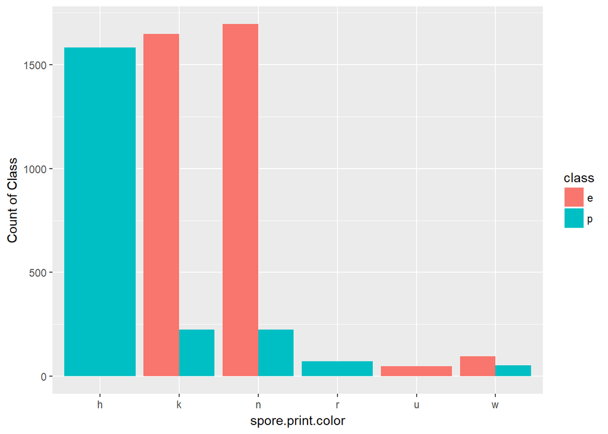

```r
hist13 <- ggplot( data_org, aes( x = data_org$spore.print.color, fill = class )) + geom_bar(stat='count', position='dodge') + labs(x = 'spore.print.color', y = 'Count of Class')
hist13
```

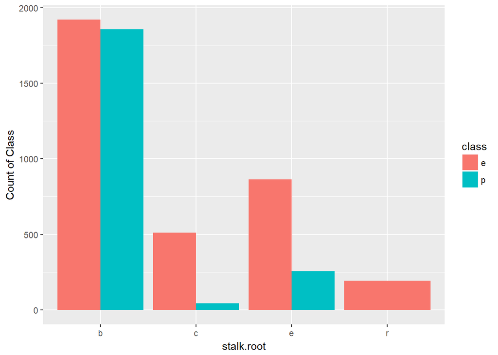

```r
hist14 <- ggplot( data_org, aes( x = data_org$stalk.root, fill = class )) + geom_bar(stat='count', position='dodge') + labs(x = 'stalk.root', y = 'Count of Class')
hist14
```

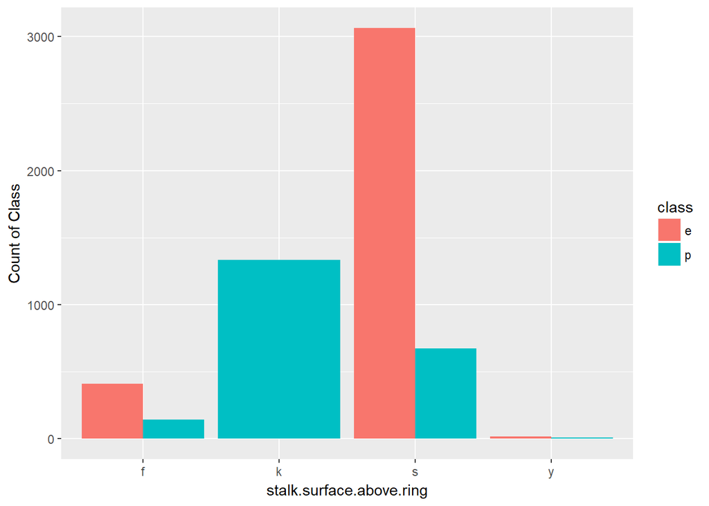

```r
hist15 <- ggplot( data_org, aes( x = data_org$stalk.surface.above.ring, fill = class )) + geom_bar(stat='count', position='dodge') + labs(x = 'stalk.surface.above.ring', y = 'Count of Class')
hist15
```

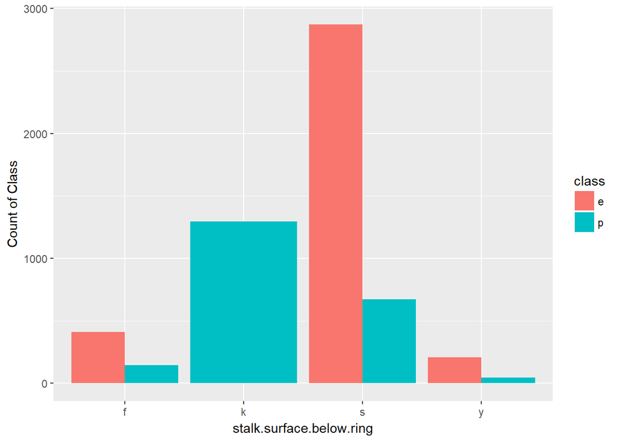

```r
hist16 <- ggplot( data_org, aes( x = data_org$stalk.surface.below.ring, fill = class )) + geom_bar(stat='count', position='dodge') + labs(x = 'stalk.surface.below.ring', y = 'Count of Class')
hist16
```

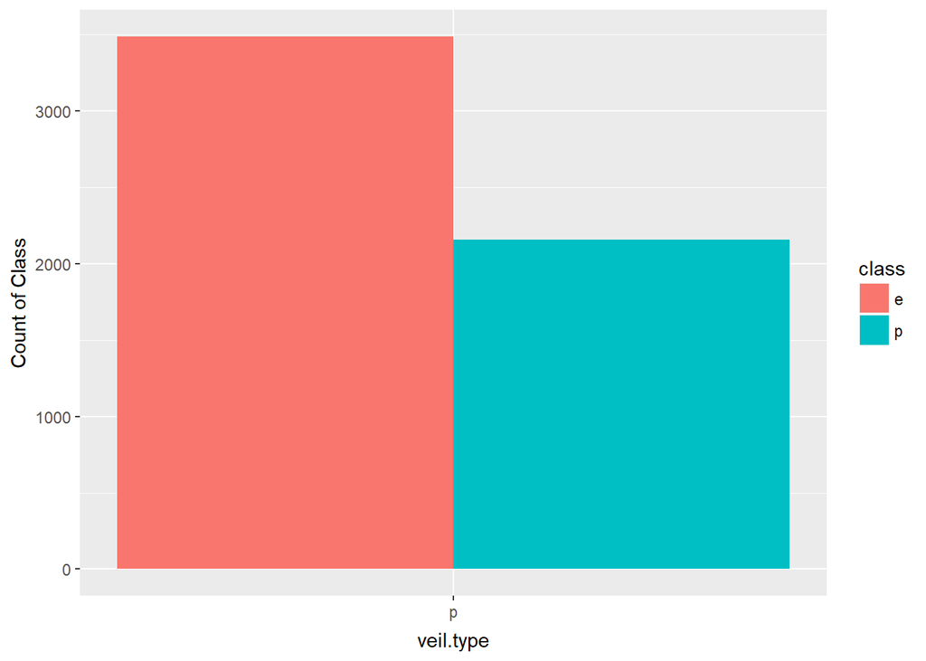

```r
hist17 <- ggplot( data_org, aes( x = data_org$veil.type, fill = class )) + geom_bar(stat='count', position='dodge') + labs(x = 'veil.type', y = 'Count of Class')
hist17
```

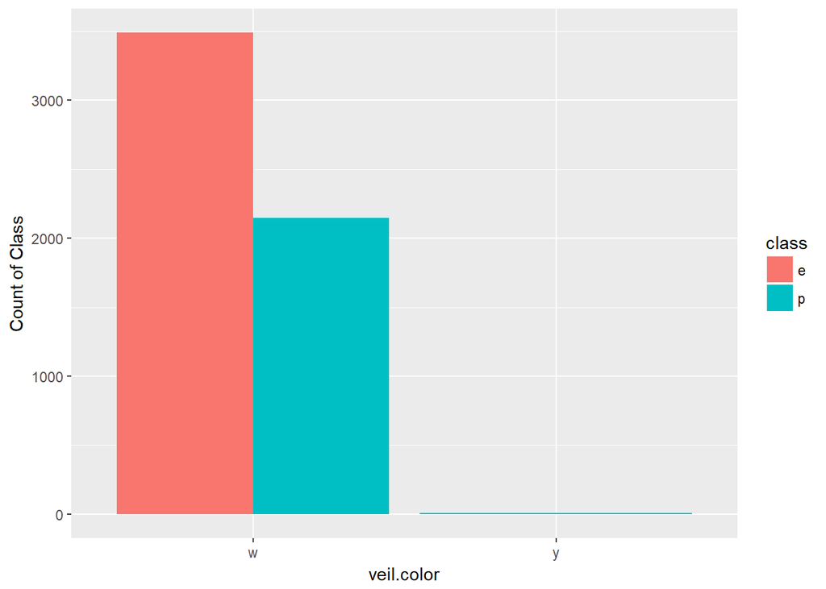

```r
hist18 <- ggplot( data_org, aes( x = data_org$veil.color, fill = class )) + geom_bar(stat='count', position='dodge') + labs(x = 'veil.color', y = 'Count of Class')
hist18
```

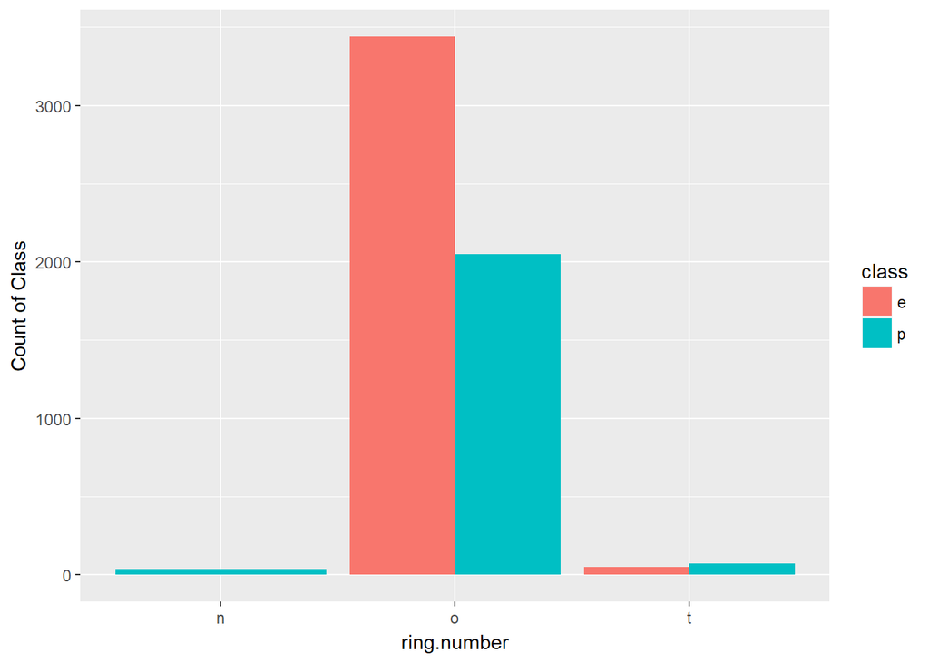

```r
hist19 <- ggplot( data_org, aes( x = data_org$ring.number, fill = class )) + geom_bar(stat='count', position='dodge') + labs(x = 'ring.number', y = 'Count of Class')
hist19
```

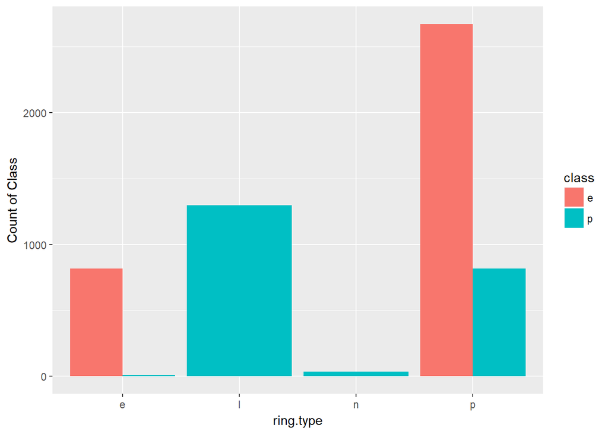

```r
hist20 <- ggplot( data_org, aes( x = data_org$ring.type, fill = class )) + geom_bar(stat='count', position='dodge') + labs(x = 'ring.type', y = 'Count of Class')
hist20
```

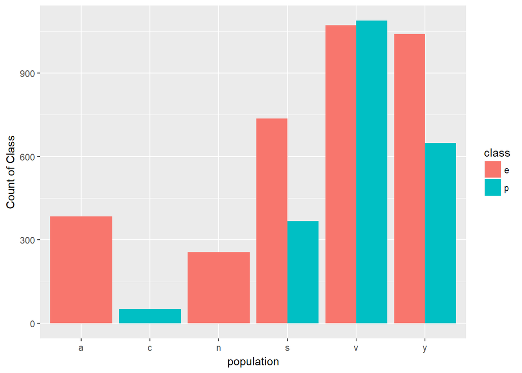

```r
hist21 <- ggplot( data_org, aes( x = data_org$population, fill = class )) + geom_bar(stat='count', position='dodge') + labs(x = 'population', y = 'Count of Class')
hist21
```

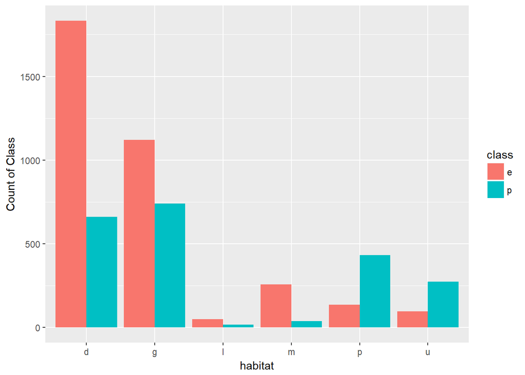

```r
hist22 <- ggplot( data_org, aes( x = data_org$habitat, fill = class )) + geom_bar(stat='count', position='dodge') + labs(x = 'habitat', y = 'Count of Class')
hist22
```

#### Since the categorical variable ‘veil’ is having only one level, set the variable values to Null as it will not help in predicting the Response Variable

```r
data=data_org
data$odor<-NULL
data$stalk.color.above.ring<-NULL
data$stalk.color.below.ring<-NULL
data$spore.print.color<-NULL
data$veil.color<-NULL
data$veil.type<-NULL
data$ring.type<-NULL
data$ring.number <- NULL
data$population <- NULL
data$cap.shape <- NULL
data$cap.surface <- NULL
data$cap.color <- NULL
data$stalk.root <- NULL
data$habitat <- NULL

dim(data)
```

```
## [1] 5644    9
```

#### **Dividing the Dataset**

```r
#randomly select 70% of the rides to the training dataset
set.seed(70)
train_data=dim(data)[1]*0.7
train_data
```

```
## [1] 3950.8
```

```r
train_class=sample(1:dim(data)[1],train_data)
# train_profit

# Default: without replacement; no prob in random division of  dataset
train_data=data[train_class,]
dim(train_data)
```

```
## [1] 3950    9
```

```r
test_data=data[-train_class,]
dim(test_data)
```

```
## [1] 1694    9
```

```r
100*summary(data$class)/(dim(data)[1])
```

```
##        e        p
## 61.80014 38.19986
```

```r
100*summary(train_data$class)/(dim(train_data)[1])
```

```
##        e        p
## 62.02532 37.97468
```

```r
100*summary(test_data$class)/(dim(test_data)[1])
```

```
##        e        p
## 61.27509 38.72491
```

#### **Bayes Logistic Regression Model**

```r
train_control<-trainControl(method="cv", number=10, verboseIter=FALSE)
M_bayesglm <- train(class ~ ., data=train_data, method="bayesglm",trControl=train_control)

cut.off.probabilities=seq(0.10,0.6,by=0.01)
MCE_bayesglm = NULL
Acc_bayesglm = NULL
Prec_bayesglm = NULL

for(cut.off.probability in cut.off.probabilities){

# Prediction ON TESTING SET
M_bayesglm.test.predict <- predict(M_bayesglm, test_data)

# Confusion Matrix - Testing & accuracy metrics

confusionMatrix(M_bayesglm.test.predict, test_data$class)
confusion.test = table(test_data$class,M_bayesglm.test.predict)
misclassification_error_bayesglm=(confusion.test[1,2]+confusion.test[2,1])/sum(confusion.test)
accuracy_bayesglm=(confusion.test[1,1]+confusion.test[2,2])/sum(confusion.test)
precision_bayesglm=confusion.test[1,1]/(confusion.test[1,1]+confusion.test[1,2])

MCE_bayesglm = c(MCE_bayesglm,misclassification_error_bayesglm)
Acc_bayesglm = c(Acc_bayesglm,accuracy_bayesglm)
Prec_bayesglm = c(Prec_bayesglm,precision_bayesglm)
}
M_bayesglm
```

```
## Bayesian Generalized Linear Model
##
## 3950 samples
##    8 predictor
##    2 classes: 'e', 'p'
##
## No pre-processing
## Resampling: Cross-Validated (10 fold)
## Summary of sample sizes: 3555, 3555, 3555, 3555, 3555, 3555, ...
## Resampling results:
##
##   Accuracy   Kappa
##   0.9174684  0.8218777
```

#### **Random Forest Model**

```r
train_RF <- train_data
test_RF <- test_data
train_yRF<- train_RF$class
test_yRF <- test_RF$class

train_RF$class <- NULL
test_RF$class <- NULL

cv.10.folds<-createMultiFolds(train_data$class,k=10,times=2)
train_control1<-trainControl(method="repeatedcv",number=10,repeats=2,index=cv.10.folds)
# M_RF <- randomForest(class ~ ., data = train_data, ntree = 500, mtry = 4, nodesize = 5, importance = "TRUE")

M_RF<-train(x=train_RF,y=train_yRF,method="rf",trControl=train_control1,tuneLength=3)

cut.off.probabilities=seq(0.10,0.6,by=0.01)
MCE_RF = NULL
Acc_RF = NULL
Prec_RF = NULL

for(cut.off.probability in cut.off.probabilities){

# Prediction ON TESTING SET
M_RF.test.predict <- predict(M_RF, test_data)

# Confusion Matrix - Testing & accuracy metrics

confusionMatrix(M_RF.test.predict, test_data$class)
confusion.test = table(test_data$class,M_RF.test.predict)
misclassification_error_RF=(confusion.test[1,2]+confusion.test[2,1])/sum(confusion.test)
accuracy_RF=(confusion.test[1,1]+confusion.test[2,2])/sum(confusion.test)
precision_RF=confusion.test[1,1]/(confusion.test[1,1]+confusion.test[1,2])

MCE_RF = c(MCE_RF,misclassification_error_RF)
Acc_RF = c(Acc_RF,accuracy_RF)
Prec_RF = c(Prec_RF,precision_RF)
}
M_RF
```

```
## Random Forest
##
## 3950 samples
##    8 predictor
##    2 classes: 'e', 'p'
##
## No pre-processing
## Resampling: Cross-Validated (10 fold, repeated 2 times)
## Summary of sample sizes: 3555, 3555, 3555, 3555, 3555, 3555, ...
## Resampling results across tuning parameters:
##
##   mtry  Accuracy   Kappa
##   2     0.9621519  0.9193211
##   5     0.9663291  0.9278949
##   8     0.9674684  0.9301044
##
## Accuracy was used to select the optimal model using  the largest value.
## The final value used for the model was mtry = 8.
```

#### **Boosting Model**

```r
train_B <- train_data
test_B <- test_data
train_yB<- train_B$class
test_yB <- test_B$class

train_B$class<-NULL
test_B$class<-NULL

# Create a stratified sample for repeated cv
cv.10.folds<-createMultiFolds(train_yB,k=8,times=2)

# create a control object for repeated cv in caret
ctrl.1<-trainControl(method="repeatedcv",number=8,repeats=2,index=cv.10.folds)

M_B<-train(x=train_B,y=train_yB, method="gbm", trControl=ctrl.1,tuneLength=3,verbose=FALSE)
cut.off.probabilities=seq(0.10,0.6,by=0.01)

MCE_B = NULL
Acc_B = NULL
Prec_B = NULL

for(cut.off.probability in cut.off.probabilities){
# Prediction ON TESTING SET
M_B.test.predict <- predict(M_B, test_data)

# Confusion Matrix - Testing & accuracy metrics

confusionMatrix(M_B.test.predict, test_data$class)
confusion.test = table(test_data$class,M_RF.test.predict)
misclassification_error_B=(confusion.test[1,2]+confusion.test[2,1])/sum(confusion.test)
accuracy_B=(confusion.test[1,1]+confusion.test[2,2])/sum(confusion.test)
precision_B=confusion.test[1,1]/(confusion.test[1,1]+confusion.test[1,2])

MCE_B = c(MCE_B,misclassification_error_B)
Acc_B = c(Acc_B,accuracy_B)
Prec_B = c(Prec_B,precision_B)
}
M_B
```

```
## Stochastic Gradient Boosting
##
## 3950 samples
##    8 predictor
##    2 classes: 'e', 'p'
##
## No pre-processing
## Resampling: Cross-Validated (8 fold, repeated 2 times)
## Summary of sample sizes: 3456, 3457, 3457, 3456, 3455, 3456, ...
## Resampling results across tuning parameters:
##
##   interaction.depth  n.trees  Accuracy   Kappa
##   1                   50      0.9026622  0.7880097
##   1                  100      0.9058247  0.7950948
##   1                  150      0.9164604  0.8192551
##   2                   50      0.9364593  0.8641701
##   2                  100      0.9565878  0.9075706
##   2                  150      0.9697539  0.9356895
##   3                   50      0.9558302  0.9059099
##   3                  100      0.9698807  0.9359511
##   3                  150      0.9684869  0.9328850
##
## Tuning parameter 'shrinkage' was held constant at a value of 0.1
##
## Tuning parameter 'n.minobsinnode' was held constant at a value of 10
## Accuracy was used to select the optimal model using  the largest value.
## The final values used for the model were n.trees = 100,
##  interaction.depth = 3, shrinkage = 0.1 and n.minobsinnode = 10.
```

#### **Decision Tree Model**

```r
train_DT <- train_data
test_DT <- test_data
train_yDT<- train_DT$class
test_yDT <- test_DT$class

train_DT$class<-NULL
test_DT$class<-NULL
# Create a stratified sample for repeated cv
cv.10.folds<-createMultiFolds(train_yDT,k=10,times=2)

# create a control object for repeated cv in caret
ctrl.1<-trainControl(method="repeatedcv",number=10,repeats=2,index=cv.10.folds)
# mod3 <-train(x=x_train,y=y_train,method="rpart",trControl=ctrl.1,tuneLength=5)

train_class<-train_data$class
M_DT <-train(x=train_DT,y=train_yDT,method="rpart",trControl=ctrl.1,tuneLength=5)

cut.off.probabilities=seq(0.10,0.6,by=0.01)
MCE_DT = NULL
Acc_DT = NULL
Prec_DT = NULL

for(cut.off.probability in cut.off.probabilities){

# Prediction ON TESTING SET
M_DT.test.predict <- predict(M_DT, test_data)

# Confusion Matrix - Testing & accuracy metrics

confusionMatrix(M_DT.test.predict, test_data$class)
confusion.test = table(test_data$class,M_DT.test.predict)
misclassification_error_DT=(confusion.test[1,2]+confusion.test[2,1])/sum(confusion.test)
accuracy_DT=(confusion.test[1,1]+confusion.test[2,2])/sum(confusion.test)
precision_DT=confusion.test[1,1]/(confusion.test[1,1]+confusion.test[1,2])

MCE_DT = c(MCE_DT,misclassification_error_DT)
Acc_DT = c(Acc_DT,accuracy_DT)
Prec_DT = c(Prec_DT,precision_DT)
}
M_DT
```

```
## CART
##
## 3950 samples
##    8 predictor
##    2 classes: 'e', 'p'
##
## No pre-processing
## Resampling: Cross-Validated (10 fold, repeated 2 times)
## Summary of sample sizes: 3555, 3555, 3555, 3555, 3555, 3555, ...
## Resampling results across tuning parameters:
##
##   cp          Accuracy   Kappa
##   0.01600000  0.9348101  0.8602442
##   0.02800000  0.9213924  0.8305310
##   0.04333333  0.8982278  0.7813234
##   0.10200000  0.8710127  0.7131465
##   0.62066667  0.7216456  0.2898095
##
## Accuracy was used to select the optimal model using  the largest value.
## The final value used for the model was cp = 0.016.
```

#### **Support Vector Machines**

```r
ctrl <- trainControl(method = "cv", savePred=T, classProb=T)
M_SVM <- train(class~., data=train_data, method = "svmLinear", trControl = ctrl)
cut.off.probabilities=seq(0.10,0.6,by=0.01)
MCE_SVM = NULL
Acc_SVM = NULL
Prec_SVM = NULL

for(cut.off.probability in cut.off.probabilities){

# Prediction ON TESTING SET
M_SVM.test.predict <- predict(M_SVM, test_data)

# Confusion Matrix - Testing & accuracy metrics

confusionMatrix(M_SVM.test.predict, test_data$class)
confusion.test = table(test_data$class,M_SVM.test.predict)
misclassification_error_SVM=(confusion.test[1,2]+confusion.test[2,1])/sum(confusion.test)
accuracy_SVM=(confusion.test[1,1]+confusion.test[2,2])/sum(confusion.test)
precision_SVM=confusion.test[1,1]/(confusion.test[1,1]+confusion.test[1,2])

MCE_SVM = c(MCE_SVM,misclassification_error_SVM)
Acc_SVM = c(Acc_SVM,accuracy_SVM)
Prec_SVM = c(Prec_SVM,precision_SVM)
}
M_SVM
```

```
## Support Vector Machines with Linear Kernel
##
## 3950 samples
##    8 predictor
##    2 classes: 'e', 'p'
##
## No pre-processing
## Resampling: Cross-Validated (10 fold)
## Summary of sample sizes: 3555, 3555, 3555, 3555, 3555, 3555, ...
## Resampling results:
##
##   Accuracy   Kappa
##   0.9237975  0.8351167
##
## Tuning parameter 'C' was held constant at a value of 1
```

```r
cat("\n Variable-importance plot produced by Train Data")
```

```
##
##  Variable-importance plot produced by Train Data
```

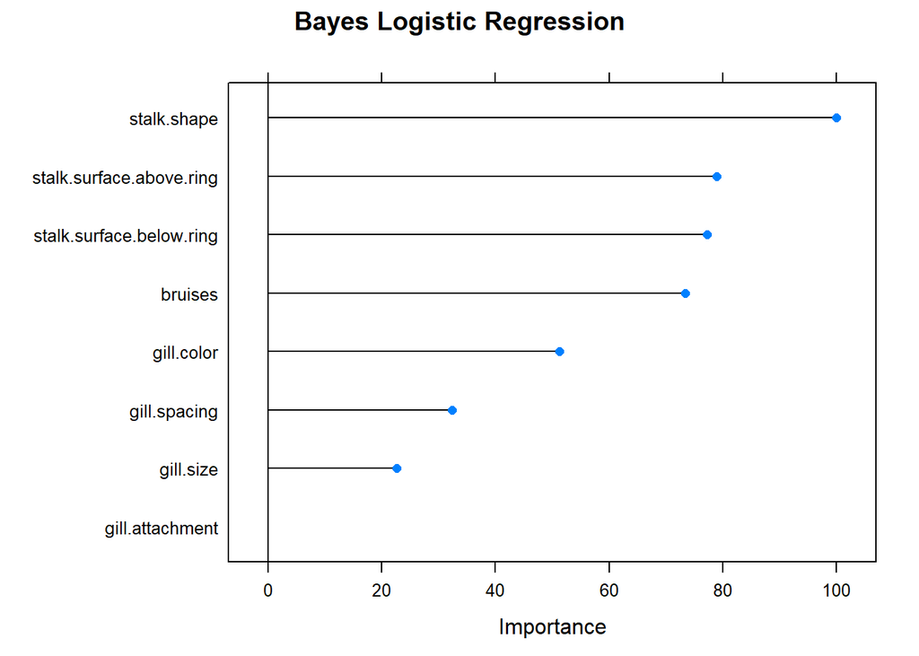

```r
par(mfrow=c(3,2))
plot(varImp(M_bayesglm),main="Bayes Logistic Regression")
```

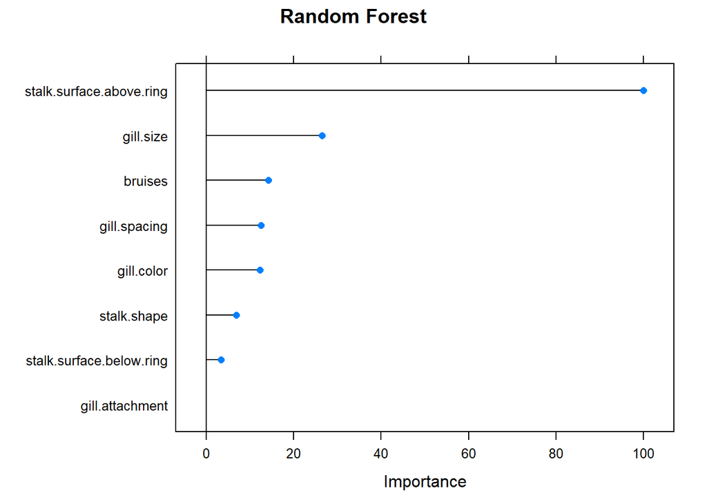

```r
plot(varImp(M_RF),main="Random Forest")
```

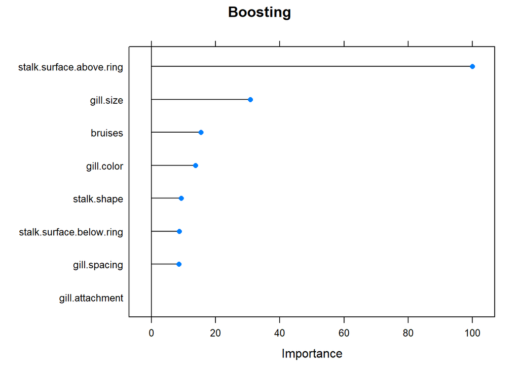

```r
plot(varImp(M_B),main="Boosting")
```

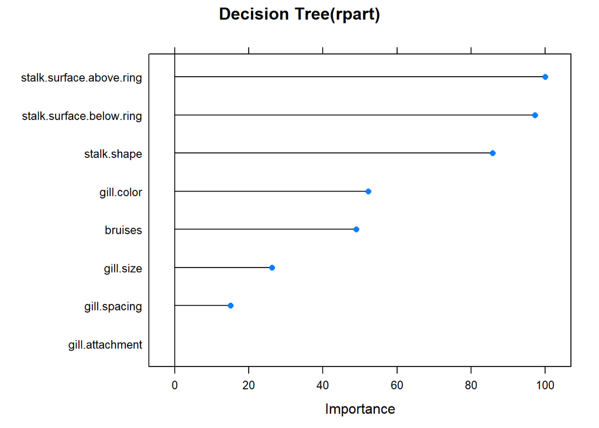

```r
plot(varImp(M_DT),main="Decision Tree(rpart)")
```

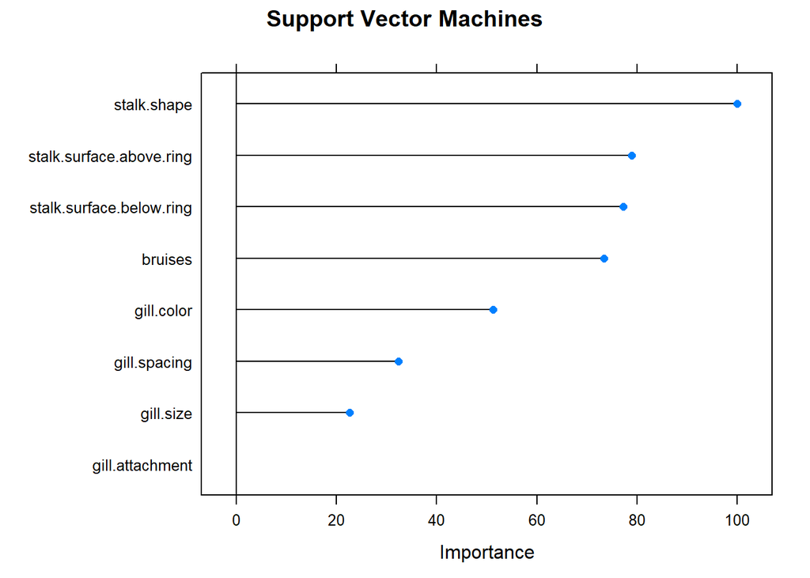

```r
plot(varImp(M_SVM),main="Support Vector Machines")
```

```r
cat("\nOptimal Cutoff and the corresponding Metrics")
```

```
##
## Optimal Cutoff and the corresponding Metrics
```

```r
cat ("\n Bayes Logistic Regression")
```

```
##
##  Bayes Logistic Regression
```

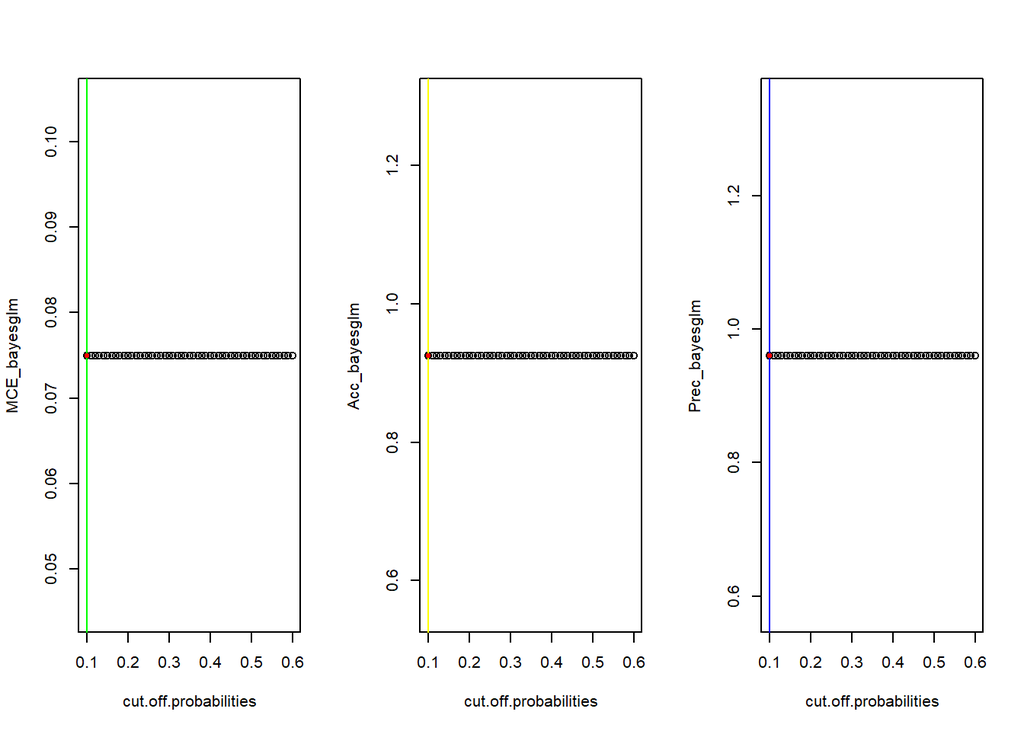

```r
par(mfrow=c(1,3))
plot(x=cut.off.probabilities,y=MCE_bayesglm)
abline(v=min(cut.off.probabilities[which(MCE_bayesglm==min(MCE_bayesglm))]), col="green")
points(x=min(cut.off.probabilities[which(MCE_bayesglm==min(MCE_bayesglm))]), y=min(MCE_bayesglm),pch=20, col="red", bg=11)

plot(x=cut.off.probabilities,y=Acc_bayesglm)
abline(v=min(cut.off.probabilities[which(Acc_bayesglm==max(Acc_bayesglm))]), col="yellow")
points(x=min(cut.off.probabilities[which(Acc_bayesglm==max(Acc_bayesglm))]), y=min(Acc_bayesglm),pch=20, col="red", bg=11)

plot(x=cut.off.probabilities,y=Prec_bayesglm)
abline(v=min(cut.off.probabilities[which(Prec_bayesglm==max(Prec_bayesglm))]), col="blue")
points(x=min(cut.off.probabilities[which(Prec_bayesglm==max(Prec_bayesglm))]), y=min(Prec_bayesglm),pch=20, col="red", bg=11)
```

```r
cat ("\n Random Forest")
```

```
##
##  Random Forest
```

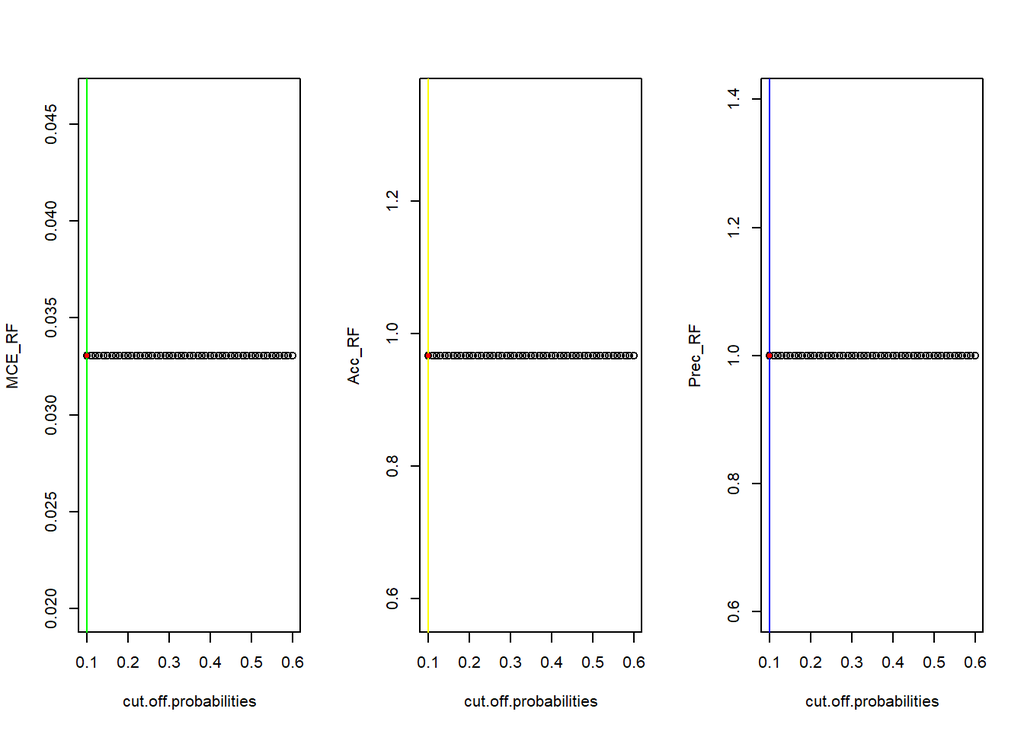

```r
par(mfrow=c(1,3))
plot(x=cut.off.probabilities,y=MCE_RF)
abline(v=min(cut.off.probabilities[which(MCE_RF==min(MCE_RF))]), col="green")
points(x=min(cut.off.probabilities[which(MCE_RF==min(MCE_RF))]), y=min(MCE_RF),pch=20, col="red", bg=11)

plot(x=cut.off.probabilities,y=Acc_RF)
abline(v=min(cut.off.probabilities[which(Acc_RF==max(Acc_RF))]), col="yellow")
points(x=min(cut.off.probabilities[which(Acc_RF==max(Acc_RF))]), y=min(Acc_RF),pch=20, col="red", bg=11)

plot(x=cut.off.probabilities,y=Prec_RF)
abline(v=min(cut.off.probabilities[which(Prec_RF==max(Prec_RF))]), col="blue")
points(x=min(cut.off.probabilities[which(Prec_RF==max(Prec_RF))]), y=min(Prec_RF),pch=20, col="red", bg=11)
```

```r
cat ("\n Decision Tree")
```

```
##
##  Decision Tree
```

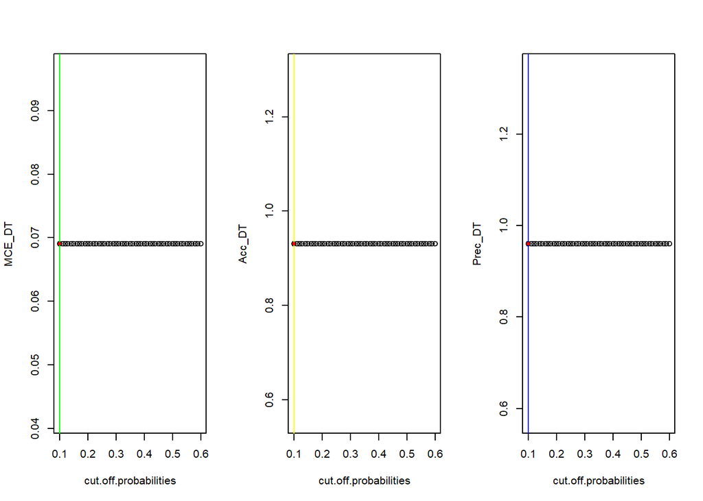

```r
par(mfrow=c(1,3))
plot(x=cut.off.probabilities,y=MCE_DT)
abline(v=min(cut.off.probabilities[which(MCE_DT==min(MCE_DT))]), col="green")
points(x=min(cut.off.probabilities[which(MCE_DT==min(MCE_DT))]), y=min(MCE_DT),pch=20, col="red", bg=11)

plot(x=cut.off.probabilities,y=Acc_DT)
abline(v=min(cut.off.probabilities[which(Acc_DT==max(Acc_DT))]), col="yellow")
points(x=min(cut.off.probabilities[which(Acc_DT==max(Acc_DT))]), y=min(Acc_DT),pch=20, col="red", bg=11)

plot(x=cut.off.probabilities,y=Prec_DT)
abline(v=min(cut.off.probabilities[which(Prec_DT==max(Prec_DT))]), col="blue")
points(x=min(cut.off.probabilities[which(Prec_DT==max(Prec_DT))]), y=min(Prec_DT),pch=20, col="red", bg=11)
```

```r
cat ("\n Support Vector Machines")
```

```
##
##  Support Vector Machines
```

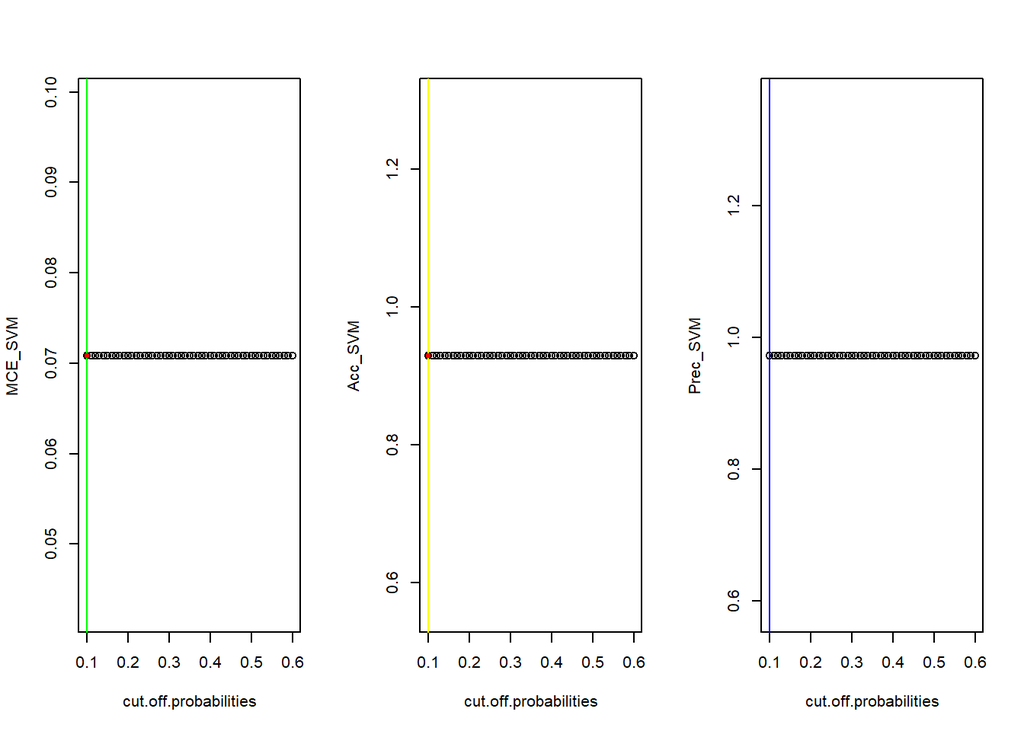

```r
par(mfrow=c(1,3))
plot(x=cut.off.probabilities,y=MCE_SVM)
abline(v=min(cut.off.probabilities[which(MCE_SVM==min(MCE_SVM))]), col="green")
points(x=min(cut.off.probabilities[which(MCE_SVM==min(MCE_SVM))]), y=min(MCE_SVM),pch=20, col="red", bg=11)

plot(x=cut.off.probabilities,y=Acc_SVM)
abline(v=min(cut.off.probabilities[which(Acc_SVM==max(Acc_SVM))]), col="yellow")
points(x=min(cut.off.probabilities[which(Acc_SVM==max(Acc_SVM))]), y=min(Acc_SVM),pch=20, col="red", bg=11)

plot(x=cut.off.probabilities,y=Prec_SVM)
abline(v=min(cut.off.probabilities[which(Prec_SVM==max(Prec_SVM))]), col="blue")
points(x=min(cut.off.probabilities[which(Prec_SVM==max(Prec_DT))]), y=min(Prec_SVM),pch=20, col="red", bg=11)
```

```r
op_cutoff_MCE_bayesglm <- min(cut.off.probabilities[which(MCE_bayesglm==min(MCE_bayesglm))])
op_cutoff_Acc_bayesglm <- min(cut.off.probabilities[which(Acc_bayesglm==min(Acc_bayesglm))])
op_cutoff_Prec_bayesglm <- min(cut.off.probabilities[which(Prec_bayesglm==min(Prec_bayesglm))])

cat("\nBayes Logistic Regression:", "\n Min. Misclassification error:", round(min(MCE_bayesglm),4), "at", op_cutoff_MCE_bayesglm,
    "\n Max. Accuracy:", round(min(Acc_bayesglm),4), "at", op_cutoff_Acc_bayesglm,
    "\n Max. Precision:", round(min(Prec_bayesglm),4), "at", op_cutoff_Prec_bayesglm)
```

```
##
## Bayes Logistic Regression:
##  Min. Misclassification error: 0.075 at 0.1
##  Max. Accuracy: 0.925 at 0.1
##  Max. Precision: 0.9605 at 0.1
```

```r
op_cutoff_MCE_RF <- min(cut.off.probabilities[which(MCE_RF==min(MCE_RF))])
op_cutoff_Acc_RF <- min(cut.off.probabilities[which(Acc_RF==min(Acc_RF))])
op_cutoff_Prec_RF <- min(cut.off.probabilities[which(Prec_RF==min(Prec_RF))])

cat("\nRandom Forest:", "\n Min. Misclassification error:", round(min(MCE_RF),4), "at", op_cutoff_MCE_RF,
    "\n Max. Accuracy:", round(min(Acc_RF),4), "at", op_cutoff_Acc_RF,
    "\n Max. Precision:", round(min(Prec_RF),4), "at", op_cutoff_Prec_RF)
```

```
##
## Random Forest:
##  Min. Misclassification error: 0.0331 at 0.1
##  Max. Accuracy: 0.9669 at 0.1
##  Max. Precision: 1 at 0.1
```

```r
op_cutoff_MCE_B <- min(cut.off.probabilities[which(MCE_B==min(MCE_B))])
op_cutoff_Acc_B <- min(cut.off.probabilities[which(Acc_B==min(Acc_B))])
op_cutoff_Prec_B <- min(cut.off.probabilities[which(Prec_B==min(Prec_B))])

cat("\nGradient Boosting:", "\n Min. Misclassification error:", round(min(MCE_B),4), "at", op_cutoff_MCE_B,
    "\n Max. Accuracy:", round(min(Acc_B),4), "at", op_cutoff_Acc_B,
    "\n Max. Precision:", round(min(Prec_B),4), "at", op_cutoff_Prec_B)
```

```
##
## Gradient Boosting:
##  Min. Misclassification error: 0.0331 at 0.1
##  Max. Accuracy: 0.9669 at 0.1
##  Max. Precision: 1 at 0.1
```

```r
op_cutoff_MCE_DT <- min(cut.off.probabilities[which(MCE_DT==min(MCE_DT))])
op_cutoff_Acc_DT <- min(cut.off.probabilities[which(Acc_DT==min(Acc_DT))])
op_cutoff_Prec_DT <- min(cut.off.probabilities[which(Prec_DT==min(Prec_DT))])

cat("\nDecision Tree:", "\n Min. Misclassification error:", round(min(MCE_DT),4), "at", op_cutoff_MCE_DT,
    "\n Max. Accuracy:", round(min(Acc_DT),4), "at", op_cutoff_Acc_DT,
    "\n Max. Precision:", round(min(Prec_DT),4), "at", op_cutoff_Prec_DT)
```

```
##
## Decision Tree:
##  Min. Misclassification error: 0.0691 at 0.1
##  Max. Accuracy: 0.9309 at 0.1
##  Max. Precision: 0.9605 at 0.1
```

```r
op_cutoff_MCE_SVM <- min(cut.off.probabilities[which(MCE_SVM==min(MCE_SVM))])
op_cutoff_Acc_SVM <- min(cut.off.probabilities[which(Acc_SVM==min(Acc_SVM))])
op_cutoff_Prec_SVM <- min(cut.off.probabilities[which(Prec_SVM==min(Prec_SVM))])

cat("\nSupport Vector Machines:", "\n Min. Misclassification error:", round(min(MCE_SVM),4), "at", op_cutoff_MCE_SVM,
    "\n Max. Accuracy:", round(min(Acc_SVM),4), "at", op_cutoff_Acc_SVM,
    "\n Max. Precision:", round(min(Prec_SVM),4), "at", op_cutoff_Prec_SVM)
```

```
##
## Support Vector Machines:
##  Min. Misclassification error: 0.0708 at 0.1
##  Max. Accuracy: 0.9292 at 0.1
##  Max. Precision: 0.9721 at 0.1
```

```r
cat("\nROC Curves")
```

```
##
## ROC Curves
```

```
##
##  Summarizing the Classification Metrics for the Mushroom Dataset
```

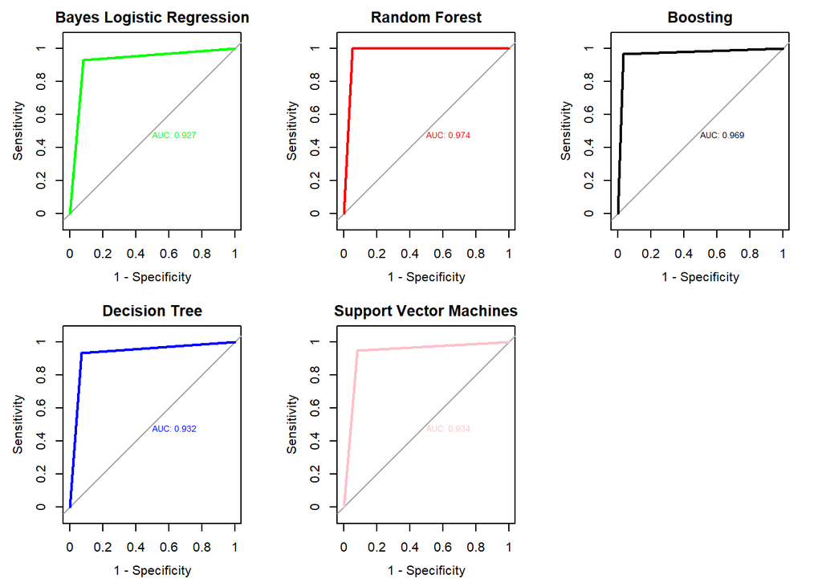

[output not shown]

```r
par(mfrow=c(2,3))
plot.roc(as.numeric(M_bayesglm.test.predict), as.numeric(test_data$class),main="Bayes Logistic Regression", axes = TRUE, legacy.axes = TRUE, print.auc = TRUE, col = "green")
plot.roc(as.numeric(M_RF.test.predict), as.numeric(test_data$class),main="Random Forest", axes = TRUE, legacy.axes = TRUE, print.auc = TRUE, col="red")
plot.roc(as.numeric(M_B.test.predict), as.numeric(test_data$class),main="Boosting", axes = TRUE, legacy.axes = TRUE, print.auc = TRUE)
plot.roc(as.numeric(M_DT.test.predict), as.numeric(test_data$class),main="Decision Tree", axes = TRUE, legacy.axes = TRUE, print.auc = TRUE, col="blue")
plot.roc(as.numeric(M_SVM.test.predict), as.numeric(test_data$class),main="Support Vector Machines", axes = TRUE, legacy.axes = TRUE, print.auc = TRUE, col="pink")
cat("\n Summarizing the Classification Metrics for the Mushroom Dataset")
```